# Effect of treatments on wildflower density

Zachary Beneduci

2023-04-011

##### Overview

The data were collected from three experimental plots established at the E.V. Smith research center in Shorter, AL. In each plot (named BEU1, FCU1, and PBU1), 16 subplots of 42 x 24 ft^2 were planted with a 20 species wildflower seed mix in spring 2022. Subplots were assigned to four groups (mowing, light-disking, their combination, and control) balanced within and across plots. These treatments were applied in fall 2022. Pre-treatment wildflower counts were collected six times (rounds) throughout the 2022 field season in each subplot from 10 randomly placed 1.25 x 0.8 m^2 quadrats. The objective of the project is to determine the effect of mowing, disking, and the combination on wildflower density, diversity, and community composition. I’ll test the hypothesis that wildflower density does not differ between treatments and the control (which we would hope for, since the treatments were not applied yet!). To do this, I will consider several variations of linear models to compare differences between each treatment to the control group. Therefore, beta estimates from regression and their associated measures of precision, will be assessed.

##### Data Preparation

Load the dataset:

```r
datum1 <- read.csv("https://raw.githubusercontent.com/beneducizachary/ENTM6820/main/ReproducibleWorkflow/Data/BMPvegDataRawZB7.csv")

str(datum1)
```

```
## 'data.frame':    2561 obs. of  144 variables:
##  $ ID                              : int  2435 2436 2437 2438 2439 2440 2441 2442 2443 2444 ...
##  $ Date                            : chr  "4/25/2022" "4/25/2022" "4/25/2022" "4/25/2022" ...
##  $ Site                            : chr  "BEU1" "BEU1" "BEU1" "BEU1" ...
##  $ Round                           : chr  "a" "a" "a" "a" ...
##  $ Coll1                           : chr  "ZJB" "ZJB" "ZJB" "ZJB" ...
##  $ Coll2                           : chr  "" "" "" "" ...
##  $ Coll3                           : chr  "" "" "" "" ...
##  $ EnteredBy                       : chr  "ZM" "ZM" "ZM" "ZM" ...
##  $ Validation                      : chr  "Error" "Correct" "Correct" "Correct" ...
##  $ Status                          : chr  "Clean" "Clean" "Clean" "Clean" ...
##  $ ValidationNotes                 : chr  "Litter and veg height flipped" "" "" "" ...
##  $ Subplot                         : int  1 1 1 1 1 2 2 2 2 2 ...
##  $ Quadrat                         : int  1 2 3 4 5 1 2 3 4 5 ...
##  $ Coord1                          : int  13 1 4 2 6 13 1 4 2 6 ...
```

[output cut: 86 more lines]

Load necessary packages:

```r
#install.packages("tidyverse")
library(tidyverse)
```

The first step is to format the dataset. It contains a number of other measurements, mostly counts from volunteer flower species.

Note: Site and Plot (as referred to above) are synonymous.

```r
datum2 <- datum1 %>%
  # Select relevant grouping variables and the planted species with counts > 0.
  select(Date, Round, Site, Subplot, Quadrat, ASTU, COTI3, CHFA2, DRAM, GAPU, HEAN2, MOPU, RUHI2) %>%
  # Filter out sampling rounds 'a' and 'b'. We did not detect any planted wildflowers in these rounds.
  filter(Round == "c"|Round == "d"|Round == "e"|Round == "f") %>%
  # Making sure counts are considered numbers.
  mutate_at(c(6:13), as.numeric) %>%
  # Replacing the empty cells filled with NAs by R with zeros.
  mutate_at(c(6:13), ~tidyr::replace_na(.,0)) %>%
  # Switch to long format for calculations.
  pivot_longer(cols = ASTU:RUHI2, names_to = "Species", values_to = "Count") %>%
  # Specify variables to group by for calculations.
  group_by(Site, Round, Subplot, Species) %>%
  # Summing counts for wildflowers across the 10 quadrats per subplot.
  summarise(Count=sum(Count)) %>%
  # Switch back to wide.
  pivot_wider(names_from = Species, values_from = Count) %>%
  # Specify we want next calculations applied across columns.
  rowwise() %>%
  mutate(
    TotalDens = sum(c_across(ASTU:RUHI2)), # Sums all counts across columns.
    Richness = sum(c_across(ASTU:RUHI2)!=0) # Counts the frequency of values >0.
  ) %>%
  # Assign subplots to columns and rows within fields for spatial visualization.
  mutate(Row =
           case_when(between(Subplot, 1, 4)~1,
                     between(Subplot, 5, 8)~2,
                     between(Subplot, 8, 12)~3,
                     between(Subplot, 13, 16)~4)) %>%
  mutate(Col =
           case_when(Subplot == 4 | Subplot == 8 | Subplot == 12 | Subplot == 16 ~ 1,
                     Subplot == 3 | Subplot == 7 | Subplot == 11 | Subplot == 15 ~ 2,
                     Subplot == 2 | Subplot == 6 | Subplot == 10 | Subplot == 14 ~ 3,
                     Subplot == 1 | Subplot == 5 | Subplot == 9 | Subplot == 13 ~ 4)) %>%
  # We'll add the treatment information.
  mutate(Treatment =
           case_when(Subplot == 1 & Site == "FCU1" ~ "Disking",
                     Subplot == 2 & Site == "FCU1" ~ "Mowing",
                     Subplot == 3 & Site == "FCU1" ~ "Combo",
                     Subplot == 4 & Site == "FCU1" ~ "Control",
                     Subplot == 5 & Site == "FCU1" ~ "Mowing",
                     Subplot == 6 & Site == "FCU1" ~ "Control",
                     Subplot == 7 & Site == "FCU1" ~ "Disking",
                     Subplot == 8 & Site == "FCU1" ~ "Combo",
                     Subplot == 9 & Site == "FCU1" ~ "Combo",
                     Subplot == 10 & Site == "FCU1" ~ "Disking",
                     Subplot == 11 & Site == "FCU1" ~ "Mowing",
                     Subplot == 12 & Site == "FCU1" ~ "Control",
                     Subplot == 13 & Site == "FCU1" ~ "Control",
                     Subplot == 14 & Site == "FCU1" ~ "Mowing",
                     Subplot == 15 & Site == "FCU1" ~ "Combo",
                     Subplot == 16 & Site == "FCU1" ~ "Disking",
                     Subplot == 1 & Site == "BEU1" ~ "Combo",
                     Subplot == 2 & Site == "BEU1" ~ "Disking",
                     Subplot == 3 & Site == "BEU1" ~ "Mowing",
                     Subplot == 4 & Site == "BEU1" ~ "Control",
                     Subplot == 5 & Site == "BEU1" ~ "Mowing",
                     Subplot == 6 & Site == "BEU1" ~ "Control",
                     Subplot == 7 & Site == "BEU1" ~ "Combo",
                     Subplot == 8 & Site == "BEU1" ~ "Disking",
                     Subplot == 9 & Site == "BEU1" ~ "Disking",
                     Subplot == 10 & Site == "BEU1" ~ "Mowing",
                     Subplot == 11 & Site == "BEU1" ~ "Control",
                     Subplot == 12 & Site == "BEU1" ~ "Combo",
                     Subplot == 13 & Site == "BEU1" ~ "Control",
                     Subplot == 14 & Site == "BEU1" ~ "Combo",
                     Subplot == 15 & Site == "BEU1" ~ "Disking",
                     Subplot == 16 & Site == "BEU1" ~ "Mowing",
                     Subplot == 1 & Site == "PBU1" ~ "Mowing",
                     Subplot == 2 & Site == "PBU1" ~ "Disking",
                     Subplot == 3 & Site == "PBU1" ~ "Combo",
                     Subplot == 4 & Site == "PBU1" ~ "Control",
                     Subplot == 5 & Site == "PBU1" ~ "Control",
                     Subplot == 6 & Site == "PBU1" ~ "Combo",
                     Subplot == 7 & Site == "PBU1" ~ "Mowing",
                     Subplot == 8 & Site == "PBU1" ~ "Disking",
                     Subplot == 9 & Site == "PBU1" ~ "Disking",
                     Subplot == 10 & Site == "PBU1" ~ "Mowing",
                     Subplot == 11 & Site == "PBU1" ~ "Combo",
                     Subplot == 12 & Site == "PBU1" ~ "Control",
                     Subplot == 13 & Site == "PBU1" ~ "Disking",
                     Subplot == 14 & Site == "PBU1" ~ "Combo",
                     Subplot == 15 & Site == "PBU1" ~ "Control",
                     Subplot == 16 & Site == "PBU1" ~ "Mowing")) %>%
  # Set treatment as a factor.
  mutate_at(c(16), as.factor) %>%
  # Relevel the Treatment variable so Control is the reference group.
  mutate(Treatment = relevel(Treatment, "Control")) %>%
  # Set Subplot variable as a factor for random effects.
  mutate_at(c(3), as.factor)
```

Our response variable is named TotalDens. It is the density of wildflower floral units within 10 m^2 for each Site x Subplot x Round combination.

Visualize the data:

Overall density:

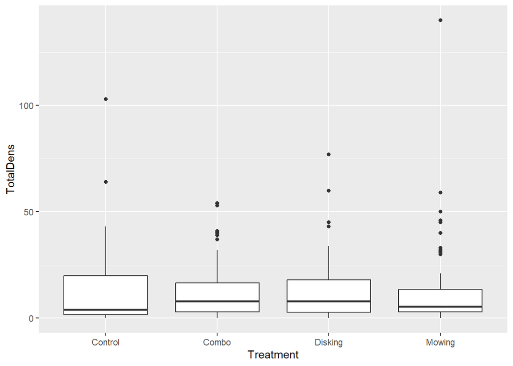

```r
ggplot(datum2, aes(x = Treatment, y = TotalDens)) +
  geom_boxplot()
```

By Site:

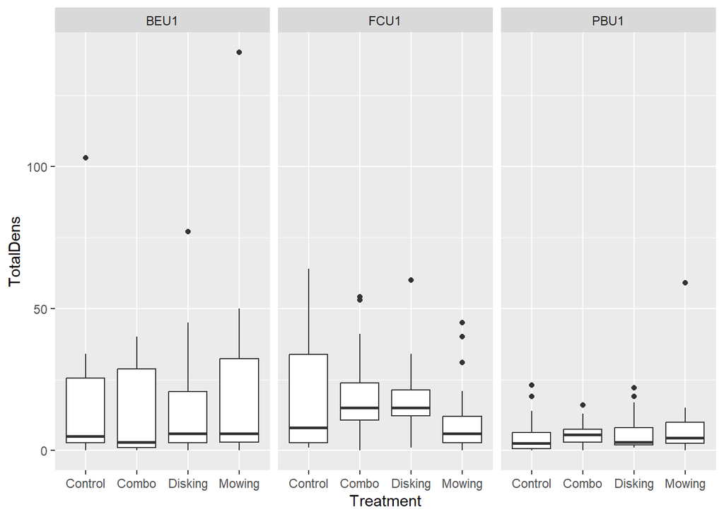

```r
ggplot(datum2, aes(x = Treatment, y = TotalDens)) +
  geom_boxplot() +
  facet_wrap(~Site)
```

By Round:

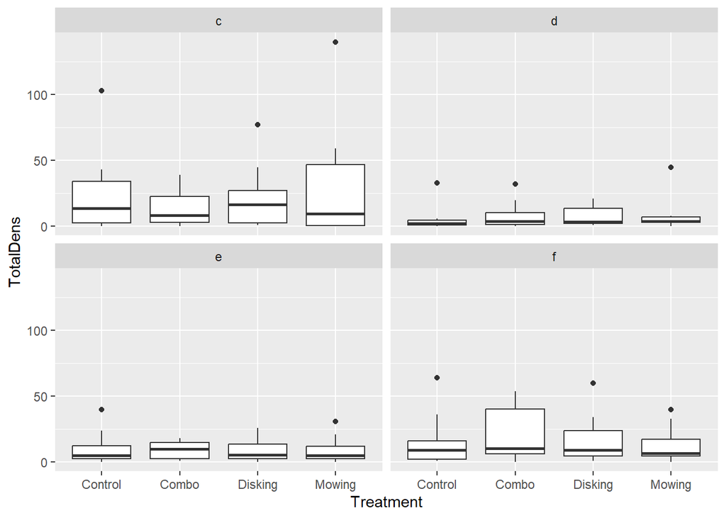

```r
ggplot(datum2, aes(x = Treatment, y = TotalDens)) +
  geom_boxplot() +
  facet_wrap(~Round)
```

By Site*Round:

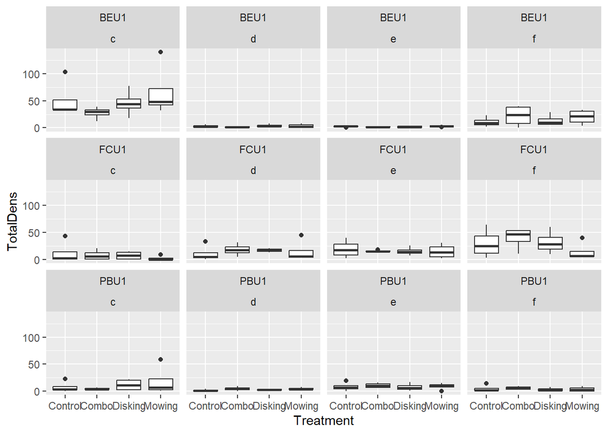

```r
ggplot(datum2, aes(x = Treatment, y = TotalDens)) +
  geom_boxplot() +
  facet_wrap(~Site*Round)
```

Looks like there is an effect of Site and Round. Of note is that boxplots are pulled towards zero, suggesting zero inflation.

Finally, look at the distribution:

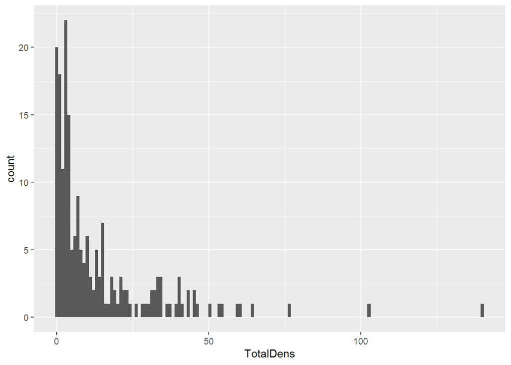

```r
ggplot(datum2, aes(x = TotalDens)) +
  geom_histogram(bins = 140)
```

##### Analysis

Our response is at least non-Gaussian. Hard to tell if the residuals are without modeling.

Of note is that subplots were sampled four times throughout the 2022 season. For the Treatment effects (of interest here), we would commit pseudoreplication if each time point is treated as an independent measurement. Additionally, subplots at the same site are not independent, so we’ll need to account for this as well.

Start with a general linear model:

```r
lm1 <- lm(TotalDens ~ Treatment, datum2)
summary(lm1)
```

```
##
## Call:
## lm(formula = TotalDens ~ Treatment, data = datum2)
##
## Residuals:
##     Min      1Q  Median      3Q     Max
## -14.542 -11.354  -7.333   4.646 125.458
##
## Coefficients:
##                  Estimate Std. Error t value Pr(>|t|)
## (Intercept)      13.33333    2.72756   4.888 2.17e-06 ***
## TreatmentCombo   -0.14583    3.85735  -0.038    0.970
## TreatmentDisking  0.02083    3.85735   0.005    0.996
## TreatmentMowing   1.20833    3.85735   0.313    0.754
## ---
## Signif. codes:  0 '***' 0.001 '**' 0.01 '*' 0.05 '.' 0.1 ' ' 1
##
## Residual standard error: 18.9 on 188 degrees of freedom
## Multiple R-squared:  0.0008489,  Adjusted R-squared:  -0.01509
## F-statistic: 0.05325 on 3 and 188 DF,  p-value: 0.9838
```

Looking at the model estimates, we can see slight differences in effect size between treatment groups. However, variation is high and none of these effects are considered significant. While we are not seeing the consequence here, running such a model could lead to inflated type I error rates, as samples from the sample plots were taken throughout the year.

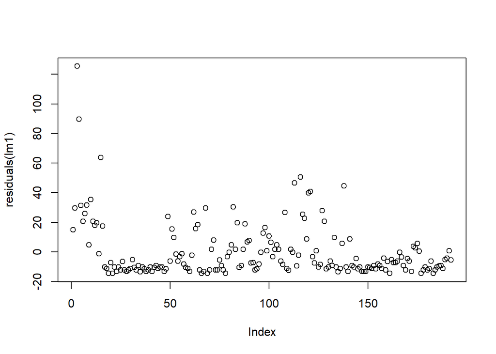

```r
plot(residuals(lm1))
```

The residuals are quite messy. More points are concentrated below zero, and those above zero are typcically higher. Additionally, the residuals are heteroscedastic.

Correct pseudoreplication with a linear mixed model:

```r
#install.packages("lme4)
library(lme4)
```

```r
lmm <- lmer(TotalDens~Treatment + (1|Site/Subplot), datum2, REML = TRUE)
```

```
## boundary (singular) fit: see help('isSingular')
```

```r
summary(lmm)
```

```
## Linear mixed model fit by REML ['lmerMod']
## Formula: TotalDens ~ Treatment + (1 | Site/Subplot)
##    Data: datum2
##
## REML criterion at convergence: 1646.5
##
## Scaled residuals:
##     Min      1Q  Median      3Q     Max
## -0.9641 -0.6653 -0.2407  0.2661  6.6735
##
## Random effects:
##  Groups       Name        Variance Std.Dev.
##  Subplot:Site (Intercept)   0.00    0.000
##  Site         (Intercept)  30.99    5.567
##  Residual                 336.00   18.330
## Number of obs: 192, groups:  Subplot:Site, 48; Site, 3
##
## Fixed effects:
##                  Estimate Std. Error t value
## (Intercept)      13.33333    4.16283   3.203
## TreatmentCombo   -0.14583    3.74166  -0.039
## TreatmentDisking  0.02083    3.74166   0.006
## TreatmentMowing   1.20833    3.74166   0.323
##
## Correlation of Fixed Effects:
##             (Intr) TrtmnC TrtmnD
## TreatmntCmb -0.449
## TrtmntDskng -0.449  0.500
## TretmntMwng -0.449  0.500  0.500
## optimizer (nloptwrap) convergence code: 0 (OK)
## boundary (singular) fit: see help('isSingular')
```

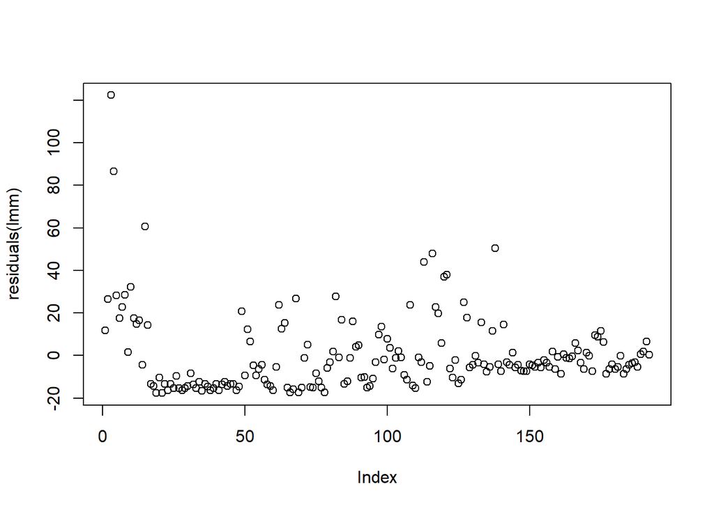

```r
plot(residuals(lmm))
```

Didn’t help the residuals much. However, it is correctly identifying that there are 3 sites and 48 subplots. The previous lm assumed that there were 192 subplots. We do have singular fit, which is expected when estimating random effects with 3 levels for Site and 4 levels for Subplot. Here, I opt to keep it to avoid pseudoreplication. Moreover, a recent paper showed that including random effects with few levels to specify nesting can only help hypothesis tests.

It’s also important to note that hierarchical models make the interpretation of raw residual plots problematic. We’ll have to turn to DHARMa package for diagnostic residual plots from here on out.

```r
#install.packages("glmmTMB")
#install.packages("DHARMa")
library(glmmTMB) # A useful package for fitting generalized linear mixed models.
library(DHARMa) # A package of diagnostic functions for such models.
```

Try poisson:

```r
pois <- glmmTMB(TotalDens ~ Treatment + (1|Site/Subplot), datum2,
                family = poisson)
summary(pois)
```

```
##  Family: poisson  ( log )
## Formula:          TotalDens ~ Treatment + (1 | Site/Subplot)
## Data: datum2
##
##      AIC      BIC   logLik deviance df.resid
##   3216.5   3236.0  -1602.2   3204.5      186
##
## Random effects:
##
## Conditional model:
##  Groups       Name        Variance Std.Dev.
##  Subplot:Site (Intercept) 0.4194   0.6476
##  Site         (Intercept) 0.1893   0.4351
## Number of obs: 192, groups:  Subplot:Site, 48; Site, 3
##
## Conditional model:
##                  Estimate Std. Error z value Pr(>|z|)
## (Intercept)        2.2167     0.3183   6.964 3.31e-12 ***
## TreatmentCombo     0.1912     0.2744   0.697    0.486
## TreatmentDisking   0.1563     0.2748   0.569    0.570
## TreatmentMowing    0.1603     0.2751   0.583    0.560
## ---
## Signif. codes:  0 '***' 0.001 '**' 0.01 '*' 0.05 '.' 0.1 ' ' 1
```

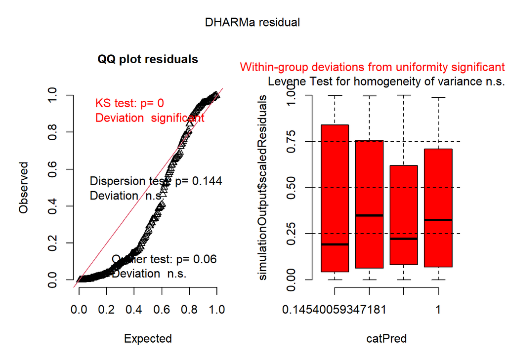

```r
plot(simulateResiduals(fittedModel = pois))
```

Negative binomial:

```r
nb <- glmmTMB(TotalDens ~ Treatment + (1|Site/Subplot), datum2,
                 family = nbinom2)
summary(nb)
```

```
##  Family: nbinom2  ( log )
## Formula:          TotalDens ~ Treatment + (1 | Site/Subplot)
## Data: datum2
##
##      AIC      BIC   logLik deviance df.resid
##   1383.8   1406.6   -684.9   1369.8      185
##
## Random effects:
##
## Conditional model:
##  Groups       Name        Variance Std.Dev.
##  Subplot:Site (Intercept) 0.01483  0.1218
##  Site         (Intercept) 0.17689  0.4206
## Number of obs: 192, groups:  Subplot:Site, 48; Site, 3
##
## Dispersion parameter for nbinom2 family (): 0.735
##
## Conditional model:
##                  Estimate Std. Error z value Pr(>|z|)
## (Intercept)       2.47291    0.31012   7.974 1.54e-15 ***
## TreatmentCombo    0.02454    0.26276   0.093    0.926
## TreatmentDisking  0.03388    0.25860   0.131    0.896
## TreatmentMowing   0.15461    0.25392   0.609    0.543
## ---
## Signif. codes:  0 '***' 0.001 '**' 0.01 '*' 0.05 '.' 0.1 ' ' 1
```

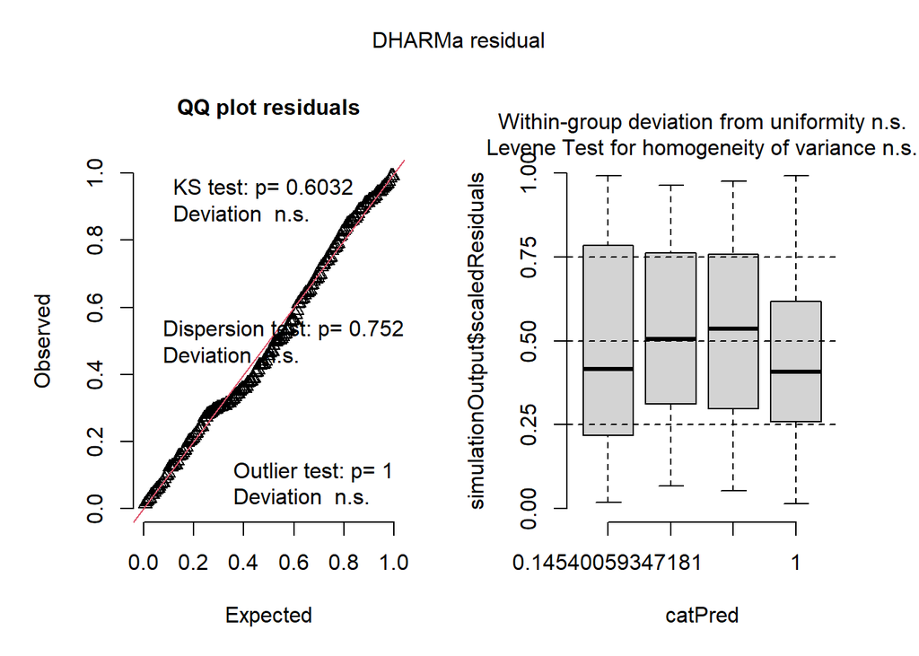

```r
plot(simulateResiduals(fittedModel = nb))
```

Zero-inflated poisson:

```r
zip <- glmmTMB(TotalDens ~ Treatment + (1|Site/Subplot), datum2,
                family = poisson, ziformula = ~1)
summary(zip)
```

```
##  Family: poisson  ( log )
## Formula:          TotalDens ~ Treatment + (1 | Site/Subplot)
## Zero inflation:             ~1
## Data: datum2
##
##      AIC      BIC   logLik deviance df.resid
##   2848.3   2871.1  -1417.1   2834.3      185
##
## Random effects:
##
## Conditional model:
##  Groups       Name        Variance Std.Dev.
##  Subplot:Site (Intercept) 0.3669   0.6057
##  Site         (Intercept) 0.1935   0.4399
## Number of obs: 192, groups:  Subplot:Site, 48; Site, 3
##
## Conditional model:
##                  Estimate Std. Error z value Pr(>|z|)
## (Intercept)        2.3192     0.3141   7.383 1.55e-13 ***
## TreatmentCombo     0.2162     0.2586   0.836    0.403
## TreatmentDisking   0.1052     0.2589   0.406    0.684
## TreatmentMowing    0.2348     0.2597   0.904    0.366
## ---
## Signif. codes:  0 '***' 0.001 '**' 0.01 '*' 0.05 '.' 0.1 ' ' 1
##
## Zero-inflation model:
##             Estimate Std. Error z value Pr(>|z|)
## (Intercept)   -2.256      0.255  -8.846   <2e-16 ***
## ---
## Signif. codes:  0 '***' 0.001 '**' 0.01 '*' 0.05 '.' 0.1 ' ' 1
```

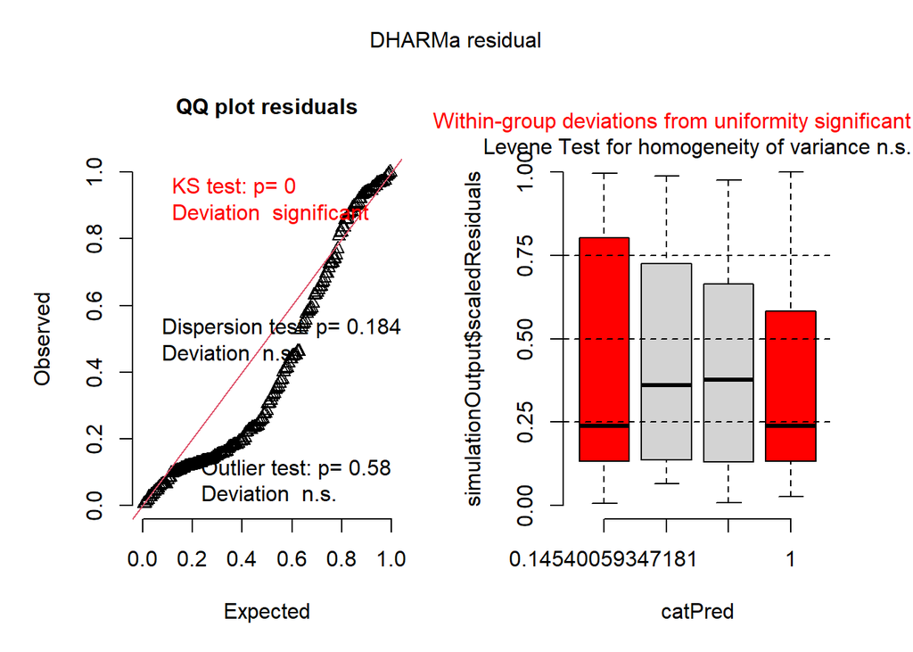

```r
plot(simulateResiduals(fittedModel = zip))
```

Zero-inflated negative binomial:

```r
zinb <- glmmTMB(TotalDens ~ Treatment + (1|Site/Subplot), datum2,
                family = nbinom2, ziformula = ~1)
summary(zinb)
```

```
##  Family: nbinom2  ( log )
## Formula:          TotalDens ~ Treatment + (1 | Site/Subplot)
## Zero inflation:             ~1
## Data: datum2
##
##      AIC      BIC   logLik deviance df.resid
##   1385.8   1411.8   -684.9   1369.8      184
##
## Random effects:
##
## Conditional model:
##  Groups       Name        Variance Std.Dev.
##  Subplot:Site (Intercept) 0.01482  0.1218
##  Site         (Intercept) 0.17688  0.4206
## Number of obs: 192, groups:  Subplot:Site, 48; Site, 3
##
## Dispersion parameter for nbinom2 family (): 0.735
##
## Conditional model:
##                  Estimate Std. Error z value Pr(>|z|)
## (Intercept)       2.47291    0.31013   7.974 1.54e-15 ***
## TreatmentCombo    0.02454    0.26276   0.093    0.926
## TreatmentDisking  0.03388    0.25860   0.131    0.896
## TreatmentMowing   0.15461    0.25392   0.609    0.543
## ---
## Signif. codes:  0 '***' 0.001 '**' 0.01 '*' 0.05 '.' 0.1 ' ' 1
##
## Zero-inflation model:
##             Estimate Std. Error z value Pr(>|z|)
## (Intercept)   -19.76    4260.05  -0.005    0.996
```

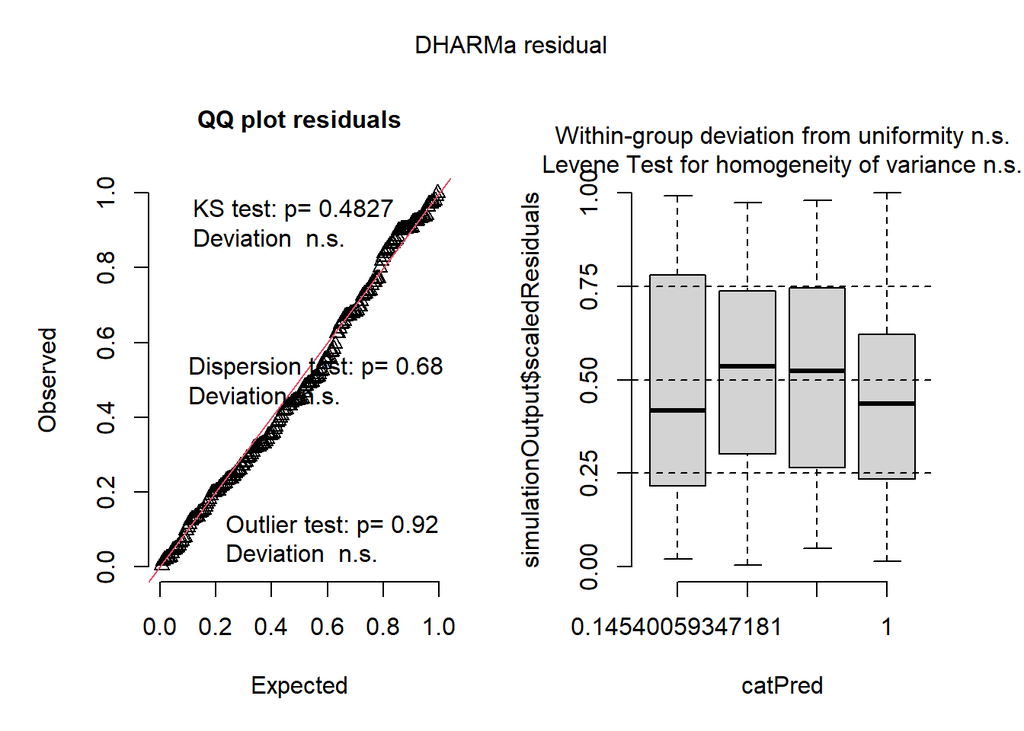

```r
plot(simulateResiduals(fittedModel = zinb))
```

Inspecting the DHARMa residual plots shows that the negative binomial and its zero-inflated counterpart fit far better than both poisson models. The regular negative binomial looks best, as the model complexity added by the zero inflated portion doesn’t provide much improvement.

Can also inspect the AIC score for a measure of model fit:

```r
anova(pois, nb, zip, zinb)
```

```
## Data: datum2
## Models:
## pois: TotalDens ~ Treatment + (1 | Site/Subplot), zi=~0, disp=~1
## nb: TotalDens ~ Treatment + (1 | Site/Subplot), zi=~0, disp=~1
## zip: TotalDens ~ Treatment + (1 | Site/Subplot), zi=~1, disp=~1
## zinb: TotalDens ~ Treatment + (1 | Site/Subplot), zi=~1, disp=~1
##      Df    AIC    BIC   logLik deviance  Chisq Chi Df Pr(>Chisq)
## pois  6 3216.5 3236.0 -1602.23   3204.5
## nb    7 1383.8 1406.6  -684.88   1369.8 1834.7      1     <2e-16 ***
## zip   7 2848.3 2871.1 -1417.13   2834.3    0.0      0          1
## zinb  8 1385.8 1411.8  -684.88   1369.8 1464.5      1     <2e-16 ***
## ---
## Signif. codes:  0 '***' 0.001 '**' 0.01 '*' 0.05 '.' 0.1 ' ' 1
```

The classic negative binomial has the lowest AIC, although the delta AIC between the nb and zinb is exact 2. This would warrant considering both models as well supported, as a penalty is added to the AIC score for number of parameters, so the AIC score will rise slightly by estimating the intercept of the zero-inflation side of the model.

I’ll opt for the more parsimonious model, the nb, rather than the more complex zinb. Additionally, the estimates don’t change between the two.

We can also compare the nb with and without random effects.

First fit a model without random effects:

```r
nb2 <- glmmTMB(TotalDens ~ Treatment, datum2, family = nbinom2)
summary(nb2)
```

```
##  Family: nbinom2  ( log )
## Formula:          TotalDens ~ Treatment
## Data: datum2
##
##      AIC      BIC   logLik deviance df.resid
##   1392.5   1408.8   -691.2   1382.5      187
##
##
## Dispersion parameter for nbinom2 family (): 0.661
##
## Conditional model:
##                   Estimate Std. Error z value Pr(>|z|)
## (Intercept)       2.590264   0.181839  14.245   <2e-16 ***
## TreatmentCombo   -0.010996   0.257192  -0.043    0.966
## TreatmentDisking  0.001565   0.257154   0.006    0.995
## TreatmentMowing   0.086756   0.256906   0.338    0.736
## ---
## Signif. codes:  0 '***' 0.001 '**' 0.01 '*' 0.05 '.' 0.1 ' ' 1
```

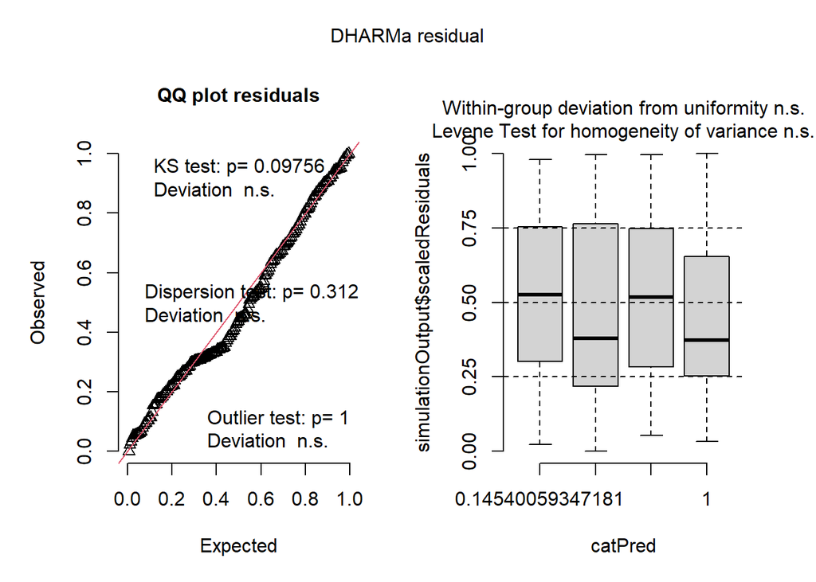

```r
plot(simulateResiduals(fittedModel = nb2))
```

Now compare:

```r
anova(nb2, nb)
```

```
## Data: datum2
## Models:
## nb2: TotalDens ~ Treatment, zi=~0, disp=~1
## nb: TotalDens ~ Treatment + (1 | Site/Subplot), zi=~0, disp=~1
##     Df    AIC    BIC  logLik deviance  Chisq Chi Df Pr(>Chisq)
## nb2  5 1392.5 1408.8 -691.24   1382.5
## nb   7 1383.8 1406.6 -684.88   1369.8 12.728      2   0.001722 **
## ---
## Signif. codes:  0 '***' 0.001 '**' 0.01 '*' 0.05 '.' 0.1 ' ' 1
```

And we get a better fit with the random effects.

Remember that our quick plots of the data show that Round is interacting with counts, which is expected. Therefore, we should consider it’s inclusion:

Consider Treatment effects consistent across Rounds:

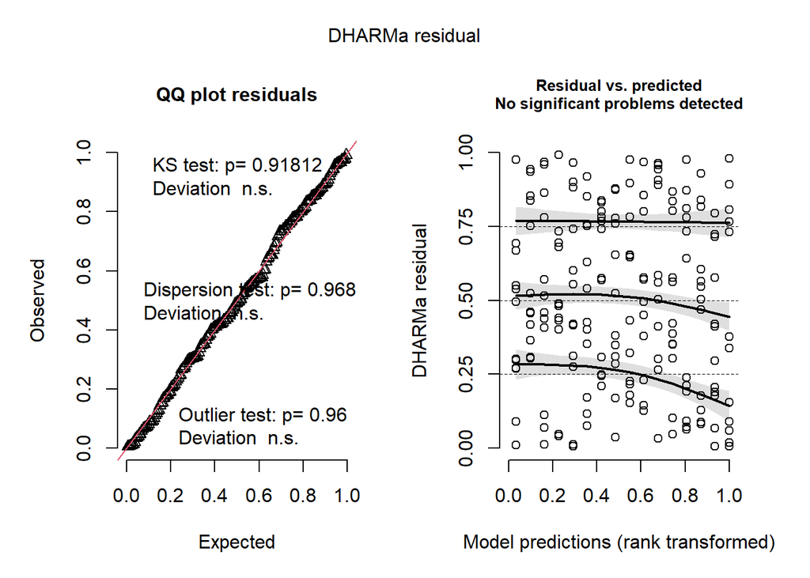

```r
nb3 <- glmmTMB(TotalDens ~ Treatment + Round + (1|Site/Subplot), datum2,
               family = nbinom2)
plot(simulateResiduals(nb3))
```

And now Round modifies the effect of Treatments via an interaction:

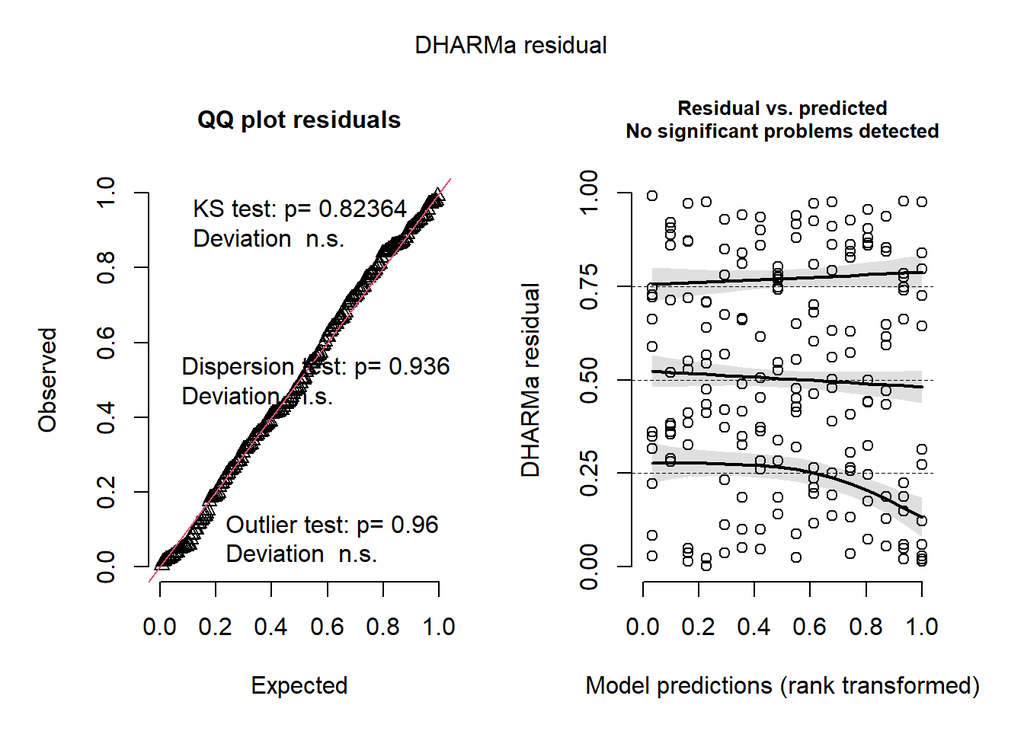

```r
nb4 <- glmmTMB(TotalDens ~ Treatment*Round + (1|Site/Subplot), datum2,
               family = nbinom2)
plot(simulateResiduals(fittedModel = nb4))
```

And let’s compare them to the model without Round:

```r
anova(nb, nb3, nb4)
```

```
## Data: datum2
## Models:
## nb: TotalDens ~ Treatment + (1 | Site/Subplot), zi=~0, disp=~1
## nb3: TotalDens ~ Treatment + Round + (1 | Site/Subplot), zi=~0, disp=~1
## nb4: TotalDens ~ Treatment * Round + (1 | Site/Subplot), zi=~0, disp=~1
##     Df    AIC    BIC  logLik deviance   Chisq Chi Df Pr(>Chisq)
## nb   7 1383.8 1406.6 -684.88   1369.8
## nb3 10 1360.0 1392.6 -670.00   1340.0 29.7620      3  1.549e-06 ***
## nb4 19 1371.6 1433.5 -666.81   1333.6  6.3784      9     0.7015
## ---
## Signif. codes:  0 '***' 0.001 '**' 0.01 '*' 0.05 '.' 0.1 ' ' 1
```

AIC shows that nb3, the model with + Round, fits better than the models without Round and a Treatment*Round interaction, respectively. Additionally, DHARMa diagnotics do not suggest any problems with model fit.

We may expect there to be an interaction of Treatment and Round in the future, but this dataset (where treatment effects should actually not be present) supports the simpler model.

Create a model selection table for all models:

```r
#install.packages("AICcmodavg")
#install.packages("kimisc")
library(AICcmodavg)
library(kimisc)
```

```r
DensAICtab <- tibble::lst(pois, nb, zip, zinb, nb2, nb3, nb4) %>%
  aictab(second.ord = TRUE) %>%
  as.data.frame() %>%
  mutate(Formula =
           case_when(Modnames == "nb3" ~ "Density ~ Treatment + Round + (1|Plot/Subplot)",
                     Modnames == "nb4" ~ "Density ~ Treatment*Round + (1|Plot/Subplot)",
                     Modnames == "nb" ~ "Density ~ Treatment + (1|Plot/Subplot)",
                     Modnames == "zinb" ~ "Density ~ Treatment + (1|Plot/Subplot)",
                     Modnames == "nb2" ~ "Density ~ Treatment",
                     Modnames == "zip" ~ "Density ~ Treatment + (1|Plot/Subplot",
                     Modnames == "pois" ~ "Density ~ Treatment + (1|Plot/Subplot")) %>%
  mutate(Family =
           case_when(Modnames == "nb3" ~ "neg.binom",
                     Modnames == "nb4" ~ "neg.binom",
                     Modnames == "nb" ~ "neg.binom",
                     Modnames == "zinb" ~ "zero.inf.neg.binom",
                     Modnames == "nb2" ~ "neg.binom",
                     Modnames == "zip" ~ "zero.inf.pois",
                     Modnames == "pois" ~ "pois")) %>%
  select(Formula, Family, AICc, Delta_AICc, K, AICcWt)

DensAICtab
```

```
##                                          Formula             Family     AICc
## 6 Density ~ Treatment + Round + (1|Plot/Subplot)          neg.binom 1361.207
## 7   Density ~ Treatment*Round + (1|Plot/Subplot)          neg.binom 1376.032
## 2         Density ~ Treatment + (1|Plot/Subplot)          neg.binom 1384.362
## 4         Density ~ Treatment + (1|Plot/Subplot) zero.inf.neg.binom 1386.540
## 5                            Density ~ Treatment          neg.binom 1392.804
## 3          Density ~ Treatment + (1|Plot/Subplot      zero.inf.pois 2848.876
## 1          Density ~ Treatment + (1|Plot/Subplot               pois 3216.905
##   Delta_AICc  K        AICcWt
## 6    0.00000 10  9.993840e-01
## 7   14.82478 19  6.033531e-04
## 2   23.15524  7  9.367745e-06
## 4   25.33343  8  3.152443e-06
## 5   31.59741  5  1.375441e-07
## 3 1487.66933  7 9.881313e-324
## 1 1855.69867  6  0.000000e+00
```

```r
# For exporting only:
#write.csv(DensAICtab, file = "C:/Classes/ENTM6280/Workflow/ENTM6820ReproducibleWorkflow/Tables/DensAICtab.csv")
```

##### Results/Summary

Let’s actually look at the results:

```r
#install.packages("ggeffects")
#install.packages("gridExtra")
#install.packages("MuMIn")
#install.packages("broom.mixed")
library(ggeffects)
library(gridExtra)
library(MuMIn)
library(broom.mixed)
# Looking at emmeans from the model.
nb3emmeans <- ggpredict(nb3)
nb3emmeans
```

```
## $Treatment
## # Predicted counts of TotalDens
##
## Treatment | Predicted |         95% CI
## --------------------------------------
## Control   |     20.96 | [10.66, 41.21]
## Combo     |     23.60 | [12.06, 46.19]
## Disking   |     22.35 | [11.63, 42.96]
## Mowing    |     25.30 | [13.07, 48.97]
##
## Adjusted for:
## *   Round = c
## * Subplot = NA (population-level)
## *    Site = NA (population-level)
##
## $Round
## # Predicted counts of TotalDens
##
## Round | Predicted |         95% CI
## ----------------------------------
## c     |     20.96 | [10.66, 41.21]
## d     |      5.26 | [ 2.66, 10.42]
## e     |      8.05 | [ 4.16, 15.56]
## f     |     12.63 | [ 6.45, 24.72]
##
## Adjusted for:
## * Treatment = Control
## *   Subplot = NA (population-level)
## *      Site = NA (population-level)
##
## attr(,"class")
## [1] "ggalleffects" "list"
## attr(,"model.name")
## [1] "nb3"
```

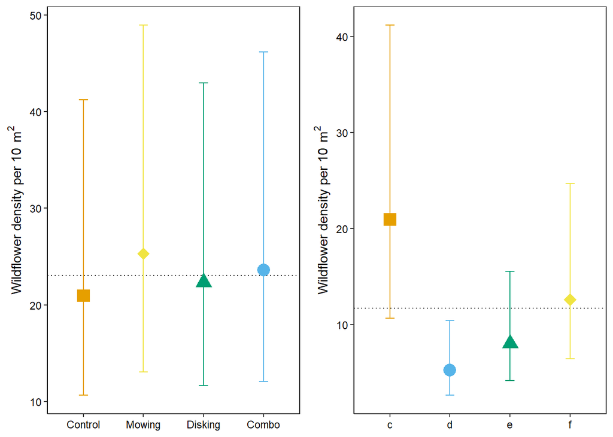

```r
cbp1 <- c("#E69F00", "#56B4E9", "#009E73",
          "#F0E442", "#0072B2", "#D55E00", "#CC79A7")

nb3TreatOut <- as.data.frame(nb3emmeans$Treatment) %>%
  ggplot(aes(x = x, y = predicted, color = x, shape = x)) +
  geom_hline(yintercept = mean(nb3emmeans$Treatment$predicted), linetype = 3) +
  geom_errorbar(aes(ymin = conf.low, ymax = conf.high, width = 0.15)) +
  geom_point(aes(size = 3)) +
  theme_classic() +
  theme(panel.border = element_rect(color = "black", fill = NA, linewidth = .5),
        axis.text = element_text(color = "black")) +
  guides(size = FALSE, color = "none", shape = "none") +
  scale_x_discrete(name = NULL, limits = c("Control", "Mowing", "Disking", "Combo")) +
  scale_y_continuous(name = bquote('Wildflower density per 10'~m^2)) +
  scale_color_manual(values = cbp1) +
  scale_shape_manual(values = c(15, 16, 17, 18))
nb3RoundOut <- as.data.frame(nb3emmeans$Round) %>%
  ggplot(aes(x = x, y = predicted, color = x, shape = x)) +
  geom_hline(yintercept = mean(nb3emmeans$Round$predicted), linetype = 3) +
  geom_errorbar(aes(ymin = conf.low, ymax = conf.high, width = 0.15)) +
  geom_point(aes(size = 3)) +
  theme_classic() +
  theme(panel.border = element_rect(color = "black", fill = NA, linewidth = .5),
        axis.text = element_text(color = "black")) +
  guides(size = FALSE, color = "none", shape = "none") +
  scale_x_discrete(name = NULL) +
  scale_y_continuous(name = bquote('Wildflower density per 10'~m^2)) +
  scale_color_manual(values = cbp1) +
  scale_shape_manual(values = c(15, 16, 17, 18))

grid.arrange(nb3TreatOut, nb3RoundOut, nrow = 1)
```

Results as rate ratios (my preference):

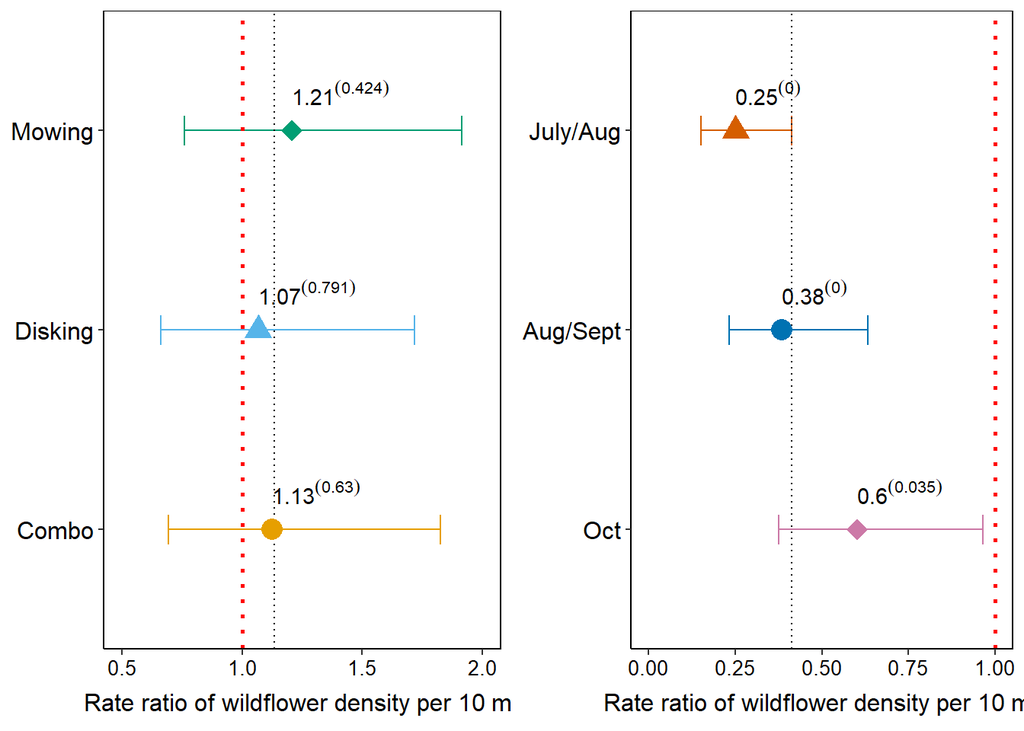

```r
# Tidy estimates for the Treatment plot.
densEstTrt <- broom.mixed::tidy(nb3, conf.int = TRUE) %>%
  mutate(expEstimate = exp(estimate)) %>%
  mutate(expConf.low = exp(conf.low)) %>%
  mutate(expConf.high = exp(conf.high)) %>%
  filter(term == 'TreatmentCombo'|term == 'TreatmentDisking'|term == 'TreatmentMowing')

# Tidy estimates for the Round plot.
densEstRnd <- broom.mixed::tidy(nb3, conf.int = TRUE) %>%
  mutate(expEstimate = exp(estimate)) %>%
  mutate(expConf.low = exp(conf.low)) %>%
  mutate(expConf.high = exp(conf.high)) %>%
  filter(term == 'Roundd'|term == 'Rounde'|term == 'Roundf')

# Plot for Treatment effects.
densTrtplot <- densEstTrt %>%
  mutate(term =
           case_when(term == "TreatmentMowing" ~ "Mowing",
                     term == "TreatmentDisking" ~ "Disking",
                     term == "TreatmentCombo" ~ "Combo")) %>%
  ggplot(aes(x = expEstimate, y = term, color = term, shape = term)) +
  geom_errorbar(aes(xmin = expConf.low, xmax = expConf.high, width = 0.15)) +
  geom_vline(xintercept = 1, linetype = 3, size = 1, color = "red") +
  geom_vline(xintercept = mean(densEstTrt$expEstimate), linetype = 3) +
  geom_point(aes(size = 2)) +
  geom_text(aes(label = paste(round(expEstimate, digits = 2),
                              "^(", round(p.value, digits = 3), ")", sep = ""),
                color = NULL, vjust = -1, hjust = -0.000001),
            parse = TRUE) +
  theme_classic() +
  theme(panel.border = element_rect(color = "black", fill = NA, linewidth = .5),
        axis.text = element_text(color = "black"),
        axis.text.y = element_text(size = 12),
        axis.text.x = element_text(size = 10),
        axis.title = element_text(size = 12)) +
  guides(size = FALSE, color = "none", shape = "none") +
  scale_y_discrete(name = NULL, limits = c("Combo", "Disking", "Mowing")) +
  scale_x_continuous(limits = c(.5,2)) +
  xlab(label = 'Rate ratio of wildflower density per 10' ~m^2) +
  scale_color_manual(values = c("#E69F00", "#56B4E9", "#009E73")) +
  scale_shape_manual(values = c(16, 17, 18))
# Plot for Round effects
densRndplot <- densEstRnd %>%
  mutate(term =
           case_when(term == "Roundd" ~ "July/Aug",
                     term == "Rounde" ~ "Aug/Sept",
                     term == "Roundf" ~ "Oct")) %>%
  ggplot(aes(x = expEstimate, y = term, color = term, shape = term)) +
  geom_errorbar(aes(xmin = expConf.low, xmax = expConf.high, width = 0.15)) +
  geom_vline(xintercept = 1, linetype = 3, size = 1, color = "red") +
  geom_vline(xintercept = mean(densEstRnd$expEstimate), linetype = 3) +
  geom_point(aes(size = 2)) +
  geom_text(aes(label = paste(round(expEstimate, digits = 2),
                              "^(", round(p.value, digits = 3), ")", sep = ""),
                color = NULL, vjust = -1, hjust = -0.000001),
            parse = TRUE) +
  theme_classic() +
  theme(panel.border = element_rect(color = "black", fill = NA, linewidth = .5),
        axis.text = element_text(color = "black"),
        axis.text.y = element_text(size = 12),
        axis.text.x = element_text(size = 10),
        axis.title = element_text(size = 12)) +
  guides(size = FALSE, color = "none", shape = "none") +
  scale_y_discrete(name = NULL, limits = c("Oct", "Aug/Sept", "July/Aug")) +
  scale_x_continuous(limits = c(0,1)) +
  xlab(label = 'Rate ratio of wildflower density per 10' ~m^2) +
  scale_color_manual(values = c("#0072B2", "#D55E00", "#CC79A7")) +
  scale_shape_manual(values = c(16, 17, 18))

# Both plots arranged.
grid.arrange(densTrtplot, densRndplot, nrow = 1)
```

```r
# Only need this if exporting:
g <- arrangeGrob(densTrtplot, densRndplot, nrow = 1)
ggsave(path = "Figures", filename = "DensFig.png", plot = g, width = 8, height = 4)
```

Note: p-values for the comparison of treatments to control the control group (left) and survey rounds to the June group (right) are supplied in the superscript. The the average of beta estimates and a rate ratio of 1 (denoting no difference) are presented as grey dotted and red dotted lines, respectively.

##### Interpretation

In terms of treatment effects, there are no significant differences between any of the treatment groups. Although the effect size of the subplots assigned to mowing are slightly higher before any of the treatments were applied. Mowing has, on average, 1.2 (0.76 - 1.92, LCL - UCL) times as many wildflowers per 10 m^2 compared to the control plots. However, this was not statistically significant (p = 0.42). This is really estimating the effect of at the time arbitray subplot groupings as the treatments were not applied. So it’s really just subplot variation.

There is high variation for these faux-effects, leading to low confidence in estimates. I’m not too surprised, as there is a lot of variation across subplots. This preliminary analysis suggests that there would need to be quite a large difference in effect size between treatments and control to detect an effect, which is slightly worrisome. I am thinking about trying a spatial autocorrelation model (such as a conditional autoregressive) or a random slopes model once my post-treatment data come in after this field season. I’m not sure how data hungry both of these approaches will be. Ultimately, separating the inital differences between subplots or estimating spatial variation should help single out treatment effects.

For sharing these results, an effects plot of the marginal means and their precision from the nb model seems most appropriate. I think it’s easier to visualize the beta coefficients and their variation in an effects plot. Additionally, an AIC table of the models considered would be good to support model choice.